# Customer purchase analysis

jsuk

2/11/2022

## Load packages

```r
library(tidyverse); library(dplyr); library(ggplot2);
library(sqldf);
```

## Load dataset

The original dataset is downloaded from Kaggle at the following [link](https://www.kaggle.com/mkechinov/ecommerce-purchase-history-from-jewelry-store). It contains purchase records from December 2018 to December 2021 (3 years) from a medium sized jewelry online store.

```r
# Load the data
colnames = c('order_date', 'order_id', 'product_id', 'quantity', 'category_id', 'category',
             'brand_id', 'price', 'user_id', 'product_gender', 'color', 'type1', 'type2')
raw = read.csv('data/jewelry.csv', col.names=colnames)
dim(raw)
```

```
[1] 95910    13
```

```r
# Explore the dataset
str(raw)
```

```
'data.frame':   95910 obs. of  13 variables:
 $ order_date    : chr  "2018-12-01 17:38:31 UTC" "2018-12-02 13:53:42 UTC" "2018-12-02 17:44:02 UTC" "2018-12-02 21:30:19 UTC" ...
 $ order_id      : num  1.92e+18 1.93e+18 1.93e+18 1.93e+18 1.93e+18 ...
 $ product_id    : num  1.81e+18 1.84e+18 1.84e+18 1.87e+18 1.84e+18 ...
 $ quantity      : int  1 1 1 1 1 1 1 1 1 1 ...
 $ category_id   : num  1.81e+18 1.81e+18 1.81e+18 1.81e+18 1.81e+18 ...
 $ category      : chr  "" "jewelry.pendant" "jewelry.pendant" "jewelry.necklace" ...
 $ brand_id      : num  NA 1 0 0 1 0 0 2 1 1 ...
 $ price         : num  212.1 54.7 88.9 417.7 102.3 ...
 $ user_id       : num  1.52e+18 1.52e+18 1.52e+18 1.52e+18 1.52e+18 ...
 $ product_gender: chr  "" "f" "f" "" ...
 $ color         : chr  "yellow" "white" "red" "red" ...
 $ type1         : chr  "gold" "gold" "gold" "gold" ...
 $ type2         : chr  "" "sapphire" "diamond" "amethyst" ...
```

```r
# Inspect rows with at least one missing values
length(which(!complete.cases(raw)))
```

```
[1] 10137
```

## Objective

In this notebook, I would like to explore the customer LTV. Firstly, I will create segments using purchase activeness measured by recency (date of the last purchase). This means that segmentation will be performed through manual filtering instead of statistical methods such as K-Means clustering. Then, LTV will be calculated using transition matrix to gauge customer purchase activeness across different segments.

Additional features will be created, for example frequency, average purchase and maximum purchase, which will be used for exploratory analysis and modeling to predict customer activeness and expected revenue.

## Clean dataset

In order to achieve the objective, we don’t need to use the entire data columns. `order_date` and `price` columns are key features to discover recency of purchases by each user (`user_id`).

```r
# Subset dataset with necessary columns
usecols = c('user_id', 'order_date', 'price')
data = raw[, colnames(raw) %in% usecols]
dim(data)
```

```
[1] 95910     3
```

```r
# Print rows with missing values
head(data[!complete.cases(data), ], 20)
```

```
                  order_date price user_id
446  2019-01-26 05:51:21 UTC    NA      NA
824  2019-02-05 08:39:25 UTC    NA      NA
1062 2019-02-14 10:54:07 UTC    NA      NA
1063 2019-02-14 10:54:07 UTC    NA      NA
1064 2019-02-14 10:55:34 UTC    NA      NA
1065 2019-02-14 10:56:18 UTC    NA      NA
1092 2019-02-15 05:40:30 UTC    NA      NA
1093 2019-02-15 05:55:50 UTC    NA      NA
1230 2019-02-19 13:07:07 UTC    NA      NA
1231 2019-02-19 13:07:07 UTC    NA      NA
1232 2019-02-19 13:07:07 UTC    NA      NA
1299 2019-02-22 09:45:41 UTC    NA      NA
1301 2019-02-22 09:59:51 UTC    NA      NA
1303 2019-02-22 11:11:26 UTC    NA      NA
1304 2019-02-22 11:12:13 UTC    NA      NA
1365 2019-02-25 07:46:14 UTC    NA      NA
1367 2019-02-25 07:57:18 UTC    NA      NA
1369 2019-02-25 08:41:25 UTC    NA      NA
1374 2019-02-25 09:53:25 UTC    NA      NA
1375 2019-02-25 09:54:03 UTC    NA      NA
```

```r
# Count unique user_id
length(unique(data$user_id))
```

```
[1] 31080
```

There are good diversity in unique users for segmentation

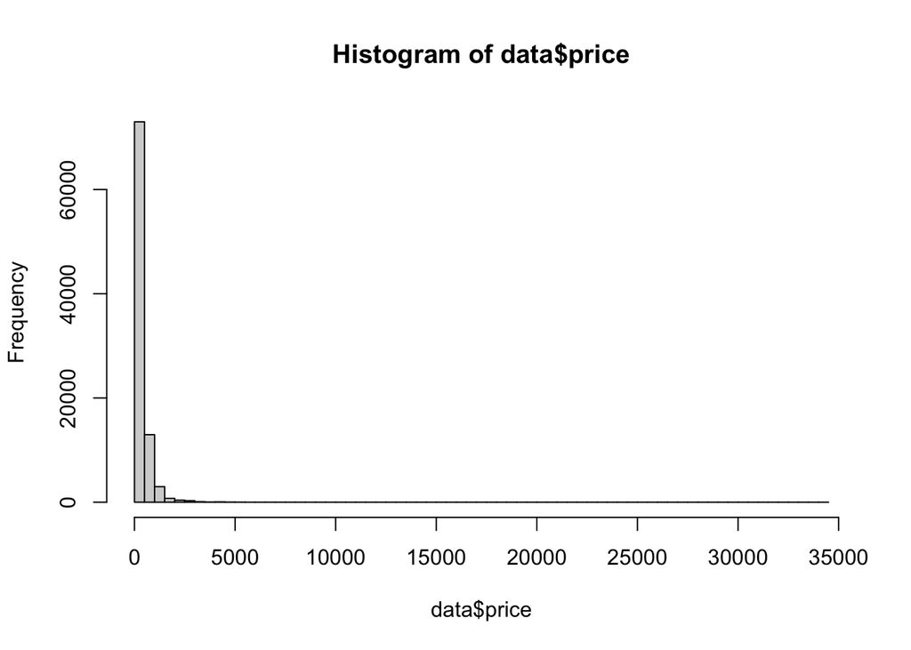

```r
# Plot histogram for price
hist(data$price, breaks=100)
```

The `price` distribution is significantly skewed. Using the mean/median imputation might not be useful. While it might be interesting to make a price prediction model based on the available features, I will leave it as a future work and focus on the objective of LTV analysis.

To continue, I will remove the incomplete records. They account for 5% of the entire dataset, which is relatively trivial as we have enough data (over 90k rows) to make inference even after removing them.

```r
# Drop rows with missing price / user_id
data = data %>% drop_na()
dim(data)
```

```
[1] 90558     3
```

I will explore customer transition based on year. To facilitate the data manipulation and analysis, convert `order_date` column to date format (%Y-%m-%d).

```r
# Change data type from character to date
data$order_date = as.Date(data$order_date)

# Extract year
data$year = as.numeric(format(data$order_date, '%Y'))
```

## Feature engineering

We will extract features needed for the analysis.

In order to make segmentation, I will make an evaluation on the purchae activeness, using metrics like recency. For more granular segmentation analysis, customer’s first purchase will also be relevant to see if the customer is relatively new or existing.

**Recency** measures when is the date of latest purchase (first purchase is the date of first ever spending which is self-explanatory). In order to calculate these two metrics, we need to set a reference date of this analysis. Given the data ranges from December 2018 to December 2021 (3 years), I will assume that this analysis is performed in early 2022.

For modeling, **frequency**, **average purchase** and **maximum purchase** will be useful to predict customer’s activeness and next purchase. These features are easier to compute. Also, unlike commodity sales such as groceries, the basket size of jewelry is not large, and I will assume that an individual **price** of a transaction represents the entire purchase.

```r
# Explore price distribution
# A single transaction accounts for fairly high receipt value (in US$)
summary(data$price)
```

```
    Min.  1st Qu.   Median     Mean  3rd Qu.     Max.
    0.99   145.62   258.77   362.21   431.37 34448.60
```

```r
# Date range for order date in the dataset
summary(data$order_date)
```

```
        Min.      1st Qu.       Median         Mean      3rd Qu.         Max.
"2018-12-01" "2020-08-08" "2021-02-22" "2020-12-30" "2021-08-09" "2021-12-01"
```

The dataset contains 3 year data ranging from 2019 to 2021.

```r
# Compute days from the reference date of analysis
ref_date = '2022-01-01'
data$days_since = as.numeric(difftime(time1=ref_date, time2=data$order_date, units='days'))
summary(data$days_since)
```

```
   Min. 1st Qu.  Median    Mean 3rd Qu.    Max.
  30.83  144.83  312.33  366.34  510.83 1126.83
```

There are many ways to aggregate the data records by user id. In order to extract all metrics as one go, I will use a sql query and the reference code will follow.

```r
# Create a SQL query to extract features
# by user_id

query = '
  SELECT user_id,
    MIN(days_since) recency,
    MAX(days_since) first_purchase,
    COUNT(*) frequency,
    AVG(price) avg_purchase,
    MAX(price) max_purchase
  FROM data
  GROUP BY user_id
  ORDER BY user_id
'

customers_2021 = sqldf(query)
tibble(customers_2021)
```

```
# A tibble: 31,079 × 6
   user_id recency first_purchase frequency avg_purchase max_purchase
     <dbl>   <dbl>          <dbl>     <int>        <dbl>        <dbl>
 1 1.31e18   553.            553.         1        272.         272.
 2 1.31e18    87.8           883.         6        636.        1219.
 3 1.31e18   135.            956.         5        563.        1520.
 4 1.31e18   166.            166.         1        130          130
 5 1.31e18   467.           1034.         8        258.         313.
 6 1.31e18   735.            736.         2         12.0         12.0
 7 1.31e18   131.           1074.        16        342.         870.
 8 1.31e18   334.            334.         1        480.         480.
 9 1.31e18   812.           1068.         7        192.         397.
10 1.31e18    50.8           801.         4        567.        2171.
# … with 31,069 more rows
```

## EDA: Exploratory analysis

Most of the features are significantly skewed to right to the extent that visualization does not provide insights very well. It may be more effective to explore summary statistics.

```r
# Explore frequency
summary(customers_2021$frequency)
```

```
    Min.  1st Qu.   Median     Mean  3rd Qu.     Max.
   1.000    1.000    1.000    2.914    2.000 1068.000
```

```r
# Explore average purchase
summary(customers_2021$avg_purchase)
```

```
    Min.  1st Qu.   Median     Mean  3rd Qu.     Max.
    1.03   136.85   232.74   316.04   378.67 15599.18
```

More than 75% (3rd quantity) purchased less than or equal to 2 purchases over the past 3 years.

The purchase cycle is pretty long whereas the purchase amount (measured in US dollars) is comparatively higher than the normal commodity goods.

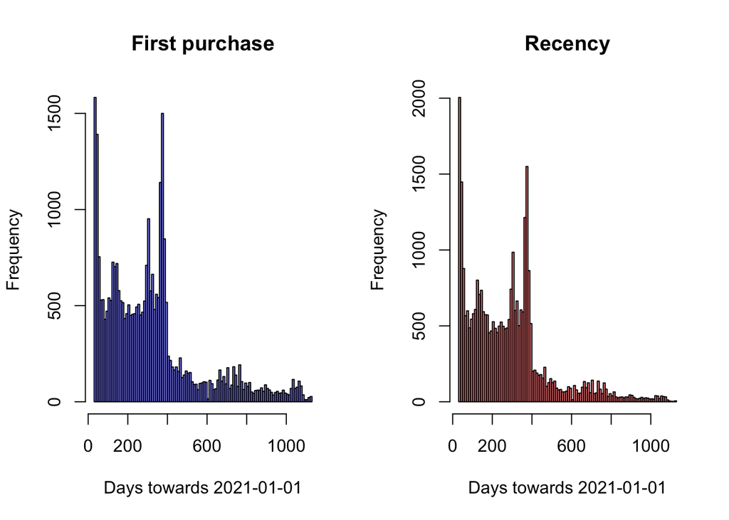

```r
# Histograms of recency and first purchase together
par(mfrow=c(1,2))
hist(customers_2021$first_purchase, col=rgb(0,0,1,1/2), breaks=100, main='First purchase', xlab='Days towards 2021-01-01')
hist(customers_2021$recency, col=rgb(1,0,0,1/2), breaks=100, main='Recency', xlab='Days towards 2021-01-01')
```

The plots shows that the distributions of first purchase and recency are very similar and overlapping. This aligns with the earlier finding that the purchase frequency is quite low in general (less than twice over 3 years) and the first and last are likely the same for customers.

Using **first_purchase** feature does not greatly provide a additional information on whether a customer is new or existing. Therefore, for the segmentation analysis the variable will be ignored (only **recency** will be used.)

## Segmentation analysis

Segmentation will be based on customer’s purchase activeness, particularly recency of the purchase. Given the nature of infrequency purchase for the high-priced, luxury jewelry, the segments will be divided up by recency on annual basis.

The criteria will be as following:

- `inactive`: recency > 2 years
- `cold` : recency between 1 to 2 years
- `active` : recency < 1 year

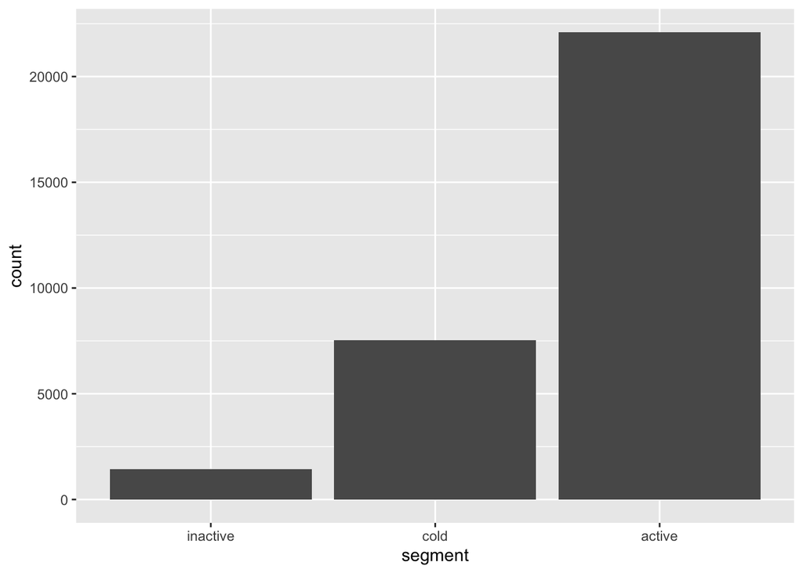

```r
# Create 'segment' feature
# by applying the criteria as above
customers_2021$segment = 'NA' # instantiate 'segment' column
customers_2021$segment[which(customers_2021$recency >= 365*2)] = 'inactive'
customers_2021$segment[which(customers_2021$recency < 365*2 & customers_2021$recency >= 365*1)] = 'cold'
customers_2021$segment[which(customers_2021$recency < 365*1)] = 'active'

# Set segment orders
customers_2021$segment = factor(customers_2021$segment, levels=c('inactive', 'cold', 'active'))

# Print the segment summary by counts
ggplot(customers_2021, aes(segment)) + geom_bar()
```

```r
# Proportion by segment in more details
prop.table(table(customers_2021$segment))
```

```
  inactive       cold     active
0.04652659 0.24231796 0.71115544
```

It is encouraging that a large number (71%) of customers are either **active**, or purchased at least one jewelry over the last year. **Inactive** customers are significantly less (5%).

## Disover customer lifetime value (LTV)

### Retrospective analysis

I would like to discover how customers move across different segments over years. This transition dynamics will be represented in a matrix. In essence, transition plays a similar role as retention rate that is used for a standard customer lifetime value (LTV) calculation.

In order to evaluate the transition between each segment, I will change my assumption that the analysis performed a year before the original reference date, therefore on 2021-01-01. This means that all transactions made in 2021 will be ignored and recency will be recalculated.

```r
query = '
  SELECT user_id,
    MIN(days_since) - 365 recency,
    MAX(days_since) - 365 first_purchase,
    COUNT(*) frequency,
    AVG(price) avg_purchase,
    MAX(price) max_purchase
  FROM data
  WHERE days_since > 365
  GROUP BY 1
  ORDER BY 1
'

customers_2020 = sqldf(query)
tibble(customers_2020)
```

```
# A tibble: 10,592 × 6
   user_id recency first_purchase frequency avg_purchase max_purchase
     <dbl>   <dbl>          <dbl>     <int>        <dbl>        <dbl>
 1 1.31e18   188.            188.         1        272.         272.
 2 1.31e18   155.            518.         2        285.         309.
 3 1.31e18   247.            591.         4        517.        1520.
 4 1.31e18   102.            669.         8        258.         313.
 5 1.31e18   370.            371.         2         12.0         12.0
 6 1.31e18    18.8           709.        13        348.         870.
 7 1.31e18   447.            703.         7        192.         397.
 8 1.31e18   292.            436.         3         31.8         82.0
 9 1.31e18   162.            193.         5        737.        1486.
10 1.31e18    55.8           709.         6         73.8        157.
# … with 10,582 more rows
```

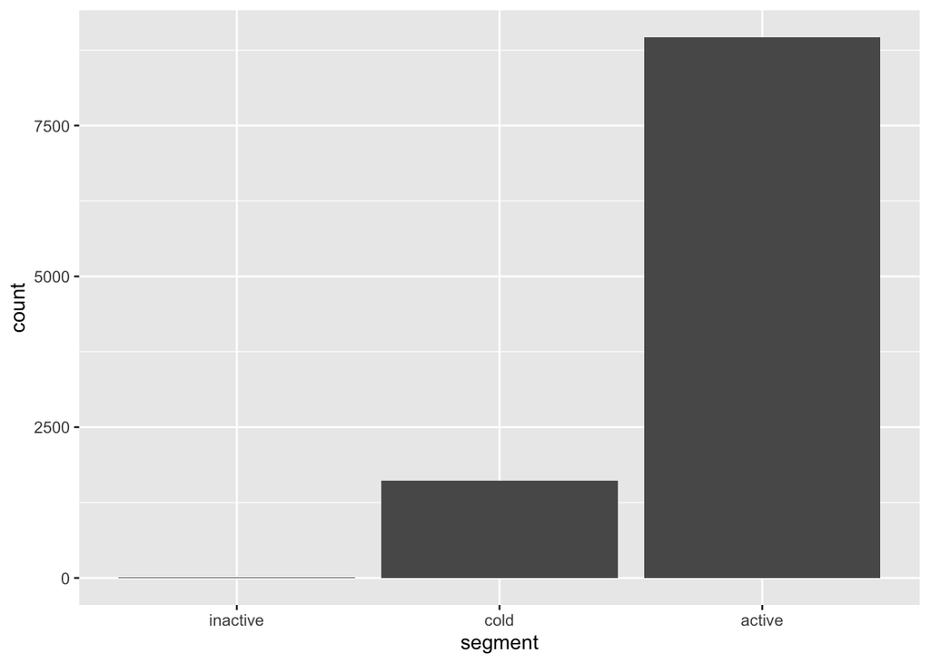

```r
# Divide segments
# by applying the same criteria as above
customers_2020$segment = 'NA' # instantiate 'segment' column
customers_2020$segment[which(customers_2020$recency >= 365*2)] = 'inactive'
customers_2020$segment[which(customers_2020$recency < 365*2 & customers_2020$recency >= 365*1)] = 'cold'
customers_2020$segment[which(customers_2020$recency < 365*1)] = 'active'

# Set segment orders
customers_2020$segment = factor(customers_2020$segment, levels=c('inactive', 'cold', 'active'))

# Print the segment summary by counts
ggplot(customers_2020, aes(segment)) + geom_bar()
```

```r
# Proportion by segment in more details
prop.table(table(customers_2020$segment))
```

```
   inactive        cold      active
0.001321752 0.152190332 0.846487915
```

In this retrospective view, active customers also take a majority (85%) as of 2020 year-end.

However, recalling the earlier analysis, standing on 2021 year-end, 71% of customers stayed active - dropped during 2021. In the meantime, albeit trivial, inactive customers became larger (nearly zero to 5%) in 2021.

### Construct a transition matrix

By combining the two subset data, I can explore the change in segment in 2021.

```r
# Combine the customers subsets
customers_composite = merge(customers_2020, customers_2021, by='user_id', all.x=TRUE) # all customers in 2020 used
tibble(customers_composite)
```

```
# A tibble: 10,592 × 13
   user_id recency.x first_purchase.x frequency.x avg_purchase.x max_purchase.x
     <dbl>     <dbl>            <dbl>       <int>          <dbl>          <dbl>
 1 1.31e18     188.              188.           1          272.           272.
 2 1.31e18     155.              518.           2          285.           309.
 3 1.31e18     247.              591.           4          517.          1520.
 4 1.31e18     102.              669.           8          258.           313.
 5 1.31e18     370.              371.           2           12.0           12.0
 6 1.31e18      18.8             709.          13          348.           870.
 7 1.31e18     447.              703.           7          192.           397.
 8 1.31e18     292.              436.           3           31.8           82.0
 9 1.31e18     162.              193.           5          737.          1486.
10 1.31e18      55.8             709.           6           73.8          157.
# … with 10,582 more rows, and 7 more variables: segment.x <fct>,
#   recency.y <dbl>, first_purchase.y <dbl>, frequency.y <int>,
#   avg_purchase.y <dbl>, max_purchase.y <dbl>, segment.y <fct>
```

```r
# Create a transition matrix using segments
transition_matrix = table(customers_composite$segment.x, customers_composite$segment.y)
transition_matrix = as.matrix(transition_matrix)
names(dimnames(transition_matrix)) = c('Segment 2021', 'Segment 2022')
transition_matrix
```

```
            Segment 2022
Segment 2021 inactive cold active
    inactive       13    0      1
    cold         1433    0    179
    active          0 7531   1435
```

```r
# Create probability matrix
transition_matrix_prob = transition_matrix / rowSums(transition_matrix)
transition_matrix_prob
```

```
            Segment 2022
Segment 2021   inactive       cold     active
    inactive 0.92857143 0.00000000 0.07142857
    cold     0.88895782 0.00000000 0.11104218
    active   0.00000000 0.83995093 0.16004907
```

A large number of customers became cold (no purchase for 1 year) from active in 2021, which is alarming. Yearly-basis retention rate is significantly low for the jewelry business due to infrequent purchase of high-priced jewelry products.

Note that there is no way that active customers become inactive within one year given the definition of criteria. Nevertheless, the large turnover from cold to inactive (89%) implies that it is very likely that the customers in cold segment will become inactive in the following year of 2022.

```r
# Exploring customers who became active from inactive over 2021.
customers_composite %>% filter(segment.x == 'inactive' & segment.y == 'active')
```

```
       user_id recency.x first_purchase.x frequency.x avg_purchase.x
1 1.515916e+18  759.8333         759.8333           1          60.27
  max_purchase.x segment.x recency.y first_purchase.y frequency.y
1          60.27  inactive  362.8333         1124.833           4
  avg_purchase.y max_purchase.y segment.y
1       236.8825         410.82    active
```

On the other hand, the rate that inactivate customers become active is very low (only 1 customer). Exploring the case will give a good insight but samples are limited in the current dataset as above - only 1 customer record found.

### Forecast customers by segment

```r
# Total spends by customer in 2021
# will then be aggregated (average) by segment

query = '
  SELECT user_id, SUM(price) total_spends_2021
  FROM data
  WHERE year = 2021
  GROUP BY user_id
  ORDER BY user_id
'

spends_2021 = sqldf(query)
tibble(spends_2021)
```

```
# A tibble: 22,102 × 2
   user_id total_spends_2021
     <dbl>             <dbl>
 1 1.31e18             3250.
 2 1.31e18              746.
 3 1.31e18              130
 4 1.31e18              949.
 5 1.31e18              480.
 6 1.31e18             2171.
 7 1.31e18              239.
 8 1.31e18              692.
 9 1.31e18              657.
10 1.31e18              198.
# … with 22,092 more rows
```

```r
# Add total spends data
# fill NA with 0 (no purchase)
customers_spends_2021 = merge(x=customers_2021, y=spends_2021, by='user_id', all.x=TRUE)
customers_spends_2021$total_spends_2021[which(is.na(customers_spends_2021$total_spends_2021))] = 0
```

```r
# Average purchase by segment in 2021
avg_segment_spends_2021 = aggregate(customers_spends_2021$total_spends_2021, by=list(customers_spends_2021$segment), mean)
avg_segment_spends_2021
```

```
   Group.1        x
1 inactive   0.0000
2     cold   0.0000
3   active 870.5524
```

```r
# Forecast for next 10 years starting from 2021 (base year)

# Instantiate forecast matrix
segment_orders = c('inactive', 'cold', 'active')
segment_forecast = matrix(nrow=length(segment_orders), ncol=11)
rownames(segment_forecast) = segment_orders
colnames(segment_forecast) = 2021:2031

# Input base year segment
segment_forecast[, 1] = table(customers_2021$segment)

# Construct the forecast using transition matrix (probability)
for (i in 2:11) {
  segment_forecast[, i] = t(segment_forecast[, i-1]) %*% transition_matrix_prob    # matrix multiplication
}
segment_forecast
```

```
          2021      2022      2023      2024      2025      2026      2027
inactive  1446  8037.456 23966.494 25597.454 26272.005 26386.052 26418.603
cold      7531 18564.595  3760.417  2815.590  2239.272  2156.761  2130.273
active   22102  4476.949  3352.089  2665.956  2567.723  2536.187  2530.124
              2028      2029      2030      2031
inactive 26425.283 26426.958 26427.329 26427.417
cold      2125.180  2123.847  2123.560  2123.490
active    2528.537  2528.195  2528.112  2528.093
```

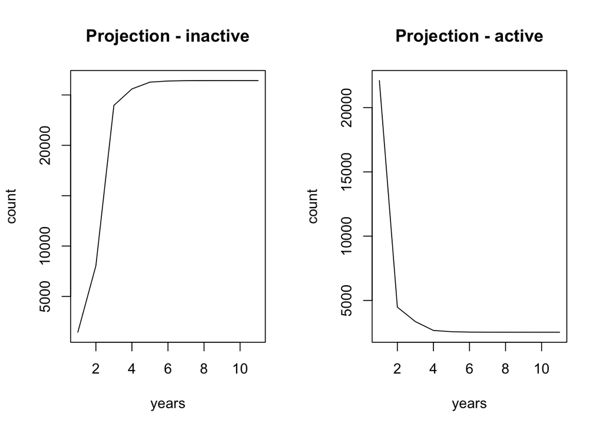

```r
# Visualize the prediction
par(mfrow=c(1,2))
plot(segment_forecast[1,], type='l', main = 'Projection - inactive', xlab='years', ylab='count')
plot(segment_forecast[3,], type='l', main = 'Projection - active', xlab='years', ylab='count')
```

As expected, inactive customers grows exponentially in the next 3 years until it gets plateaued.

### Forecast LTV by segment

```r
# Multiply average spends (in 2021) by segment
# by segment_forecast

forecast_rev = avg_segment_spends_2021$x * segment_forecast
forecast_rev
```

```
             2021    2022    2023    2024    2025    2026    2027    2028
inactive        0       0       0       0       0       0       0       0
cold            0       0       0       0       0       0       0       0
active   19240949 3897419 2918169 2320854 2235337 2207884 2202605 2201224
            2029    2030    2031
inactive       0       0       0
cold           0       0       0
active   2200926 2200854 2200837
```

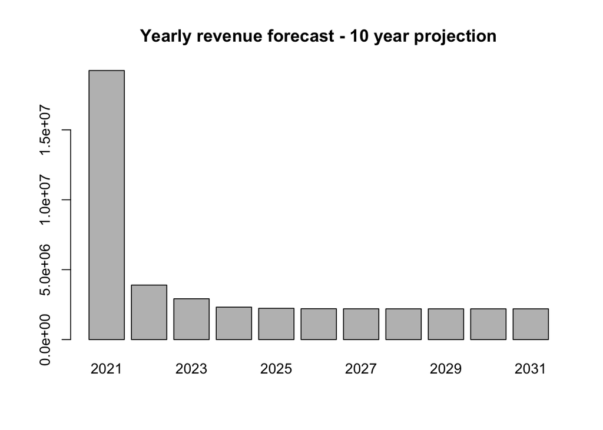

```r
# Calculate expected yearly revenue
forecast_rev_yearly = round(colSums(forecast_rev))
barplot(forecast_rev_yearly, main='Yearly revenue forecast - 10 year projection')
```

A large proportion of customers transitioning into inactive explains an exponential decay in the projected yearly revenue.

## Adjusted LTV with Discounted cash flow

The above LTV calculation does not consider the time value of money, so it does not properly reflex the cash value of the revenue projection in the current term. Let’s make a quick adjustment.

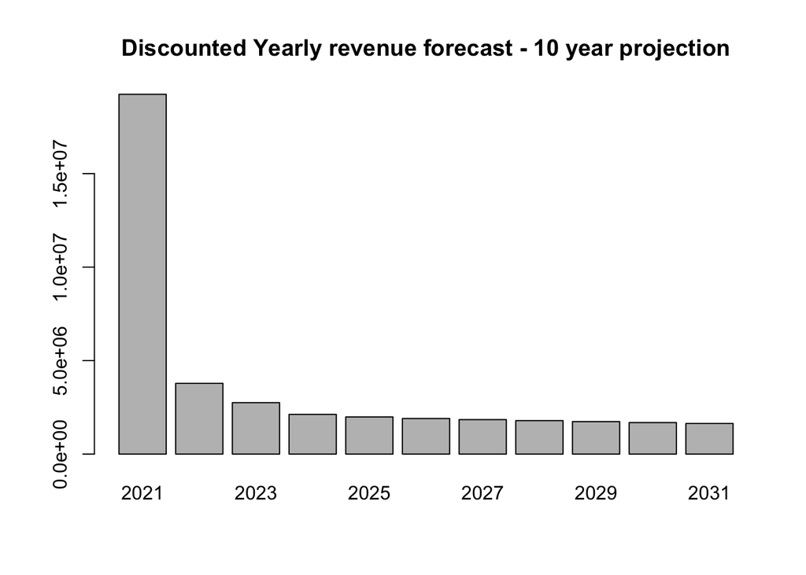

```r
# Set a yearly discount rate - 3% assumption
dc_rate = 0.03
discounts = ( 1 / (1 + dc_rate)^((1:11) - 1) ) # array of discount rate over next 10 years

# Calculate discounted revenue projection
forecast_disc_rev_yearly = forecast_rev_yearly * discounts
barplot(forecast_disc_rev_yearly, main='Discounted Yearly revenue forecast - 10 year projection')
```

## Predictive analysis

As the last step, I will build a model to make predictions for how much will an active customer purchase per a purchase (inactive customer will have no spends)

The necessary data have been all created as a result of earlier work: `spends_2021` and `customers_2020`. - **customers_spends_2021** : to create the target variables. Total spends by customer already exists in the dataset. - **customers_2020** : to extract predictor variables including recency, frequency, avg/max purchase amounts

**Note |** The following workflow does not follow the conventional machine learning practices, where train/test set is spitted for modeling fit and evaluation. Rather, it is intended to make a statistical inference.

As we are interested in active customers (inactive customers will make no spends), model should be fit using subset where customer spends in 2021 > 0.

```r
# Merge the dataset by customer id first
df_forecast = merge(customers_2020, spends_2021, by='user_id', all.x=TRUE)
head(df_forecast)
```

```
       user_id   recency first_purchase frequency avg_purchase max_purchase
1 1.313554e+18 187.83333       187.8333         1     272.4700       272.47
2 1.313556e+18 154.83333       517.8333         2     284.6200       309.27
3 1.313566e+18 246.83333       590.8333         4     516.9875      1520.41
4 1.313591e+18 101.83333       668.8333         8     258.3863       313.15
5 1.313597e+18 369.83333       370.8333         2      11.9900        11.99
6 1.313605e+18  18.83333       708.8333        13     348.2485       869.73
  segment total_spends_2021
1  active                NA
2  active           3249.55
3  active            746.44
4  active                NA
5    cold                NA
6  active            949.04
```

Null values in `total_spends_2021` column represents the customers made no spends in 2021. Therefore, create a subset by dropping NA.

```r
# Create a subset with customers with spends
df_forecast_subset = df_forecast[complete.cases(df_forecast$total_spends_2021),]
dim(df_forecast_subset)
```

```
[1] 1615    8
```

The subset lost lots of information but 1615 records will be sufficient for this simple linear model.

```r
# Construct a model
model = lm(formula=total_spends_2021~recency+avg_purchase+max_purchase, data=df_forecast_subset)
summary(model)
```

```
Call:
lm(formula = total_spends_2021 ~ recency + avg_purchase + max_purchase,
    data = df_forecast_subset)

Residuals:
    Min      1Q  Median      3Q     Max
-108242   -2811   -1820    -378  187352

Coefficients:
             Estimate Std. Error t value Pr(>|t|)
(Intercept)  3943.227    453.860   8.688  < 2e-16 ***
recency        -5.637      1.625  -3.469 0.000535 ***
avg_purchase   -8.362      1.229  -6.806 1.42e-11 ***
max_purchase    4.325      0.316  13.689  < 2e-16 ***
---
Signif. codes:  0 '***' 0.001 '**' 0.01 '*' 0.05 '.' 0.1 ' ' 1

Residual standard error: 10230 on 1611 degrees of freedom
Multiple R-squared:  0.1238,    Adjusted R-squared:  0.1222
F-statistic: 75.91 on 3 and 1611 DF,  p-value: < 2.2e-16
```

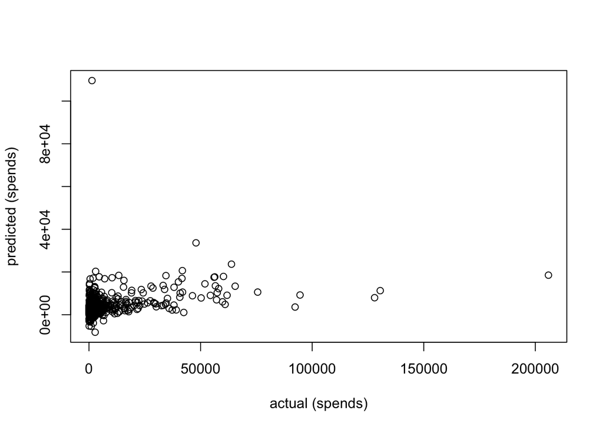

```r
# Plot to evaluate the model
plot(x=df_forecast_subset$total_spends_2021, y=model$fitted.values, xlab='actual (spends)', ylab='predicted (spends)')
```

During exploratory analysis, it is discovered that all the features are skewed. To improve the model, re-scale the features.

```r
# Construct a model
model_v2 = lm(formula=log(total_spends_2021)~log(recency)+log(avg_purchase)+log(max_purchase),
              data=df_forecast_subset)
summary(model_v2)
```

```
Call:
lm(formula = log(total_spends_2021) ~ log(recency) + log(avg_purchase) +
    log(max_purchase), data = df_forecast_subset)

Residuals:
    Min      1Q  Median      3Q     Max
-4.3039 -0.8392 -0.1137  0.7831  4.8031

Coefficients:
                  Estimate Std. Error t value Pr(>|t|)
(Intercept)        3.69007    0.23812  15.497   <2e-16 ***
log(recency)      -0.04477    0.01911  -2.343   0.0193 *
log(avg_purchase) -0.85624    0.09061  -9.450   <2e-16 ***
log(max_purchase)  1.31019    0.06965  18.811   <2e-16 ***
---
Signif. codes:  0 '***' 0.001 '**' 0.01 '*' 0.05 '.' 0.1 ' ' 1

Residual standard error: 1.267 on 1611 degrees of freedom
Multiple R-squared:  0.2935,    Adjusted R-squared:  0.2922
F-statistic: 223.1 on 3 and 1611 DF,  p-value: < 2.2e-16
```

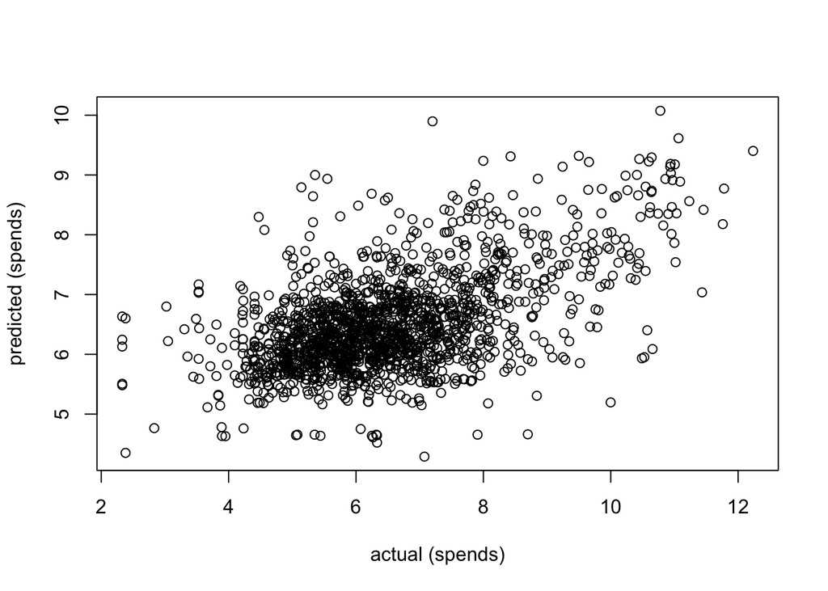

```r
plot(x=log(df_forecast_subset$total_spends_2021), y=model_v2$fitted.values,
     xlab='actual (spends)', ylab='predicted (spends)')
```

Now, the plot shows rather linear model fit between the actual and predicted spends.